# Generalisation

13/04/2022

## Motivation

When training a neural network for good performance on the training data you **also** want good performance on the testing data during evaluation. When this happens you have good **generalisation** (indicator of *real* performance). Bad generalisation can be due to:

- Overfitting
- Underfitting

## Signal and Noise

You want your neural network to learn the signal in the data but **not** the noise:

1. If you do not learn the signal you are underfitting.
2. If you learn the noise you are overfitting.

## Signal and Noise

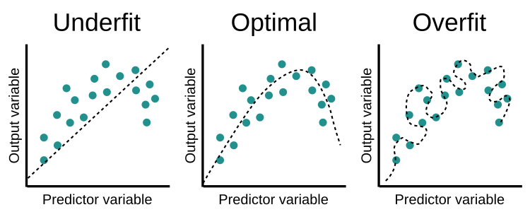

## Reason

The reason why models:

- Overfit is that they are too flexible.
- Underfit is that they are not flexible enough.

**How can we control how flexible the model is?**

## Weight Decay

**Mechanism**

1. increase # of parameters -> increase flexiblity
2. decrease # of parameters -> decrease flexiblity

We would like to avoid (2) so the model can learn the signal (if complex). We would like to only stop learning the noise. This can be done with **weight decay**. Weight decay limits the size of the weight parameters.

## Other Methods

You can also avoid learning the noise by adding **more** noise!

- **Dropout**: adds noise to the model
- **Data Augmentation**: adds noise to the data

The reason that this works is that it actually makes it harder for the model to learn the original noise.